# Classify images according to cell-type

## Testing with the test set (leNet)

Now we test our leNet models on the test set

```python
# Initialize test generator
test_data_small['cellType'] = test_data_small['cellType'].astype('str')
test_datagen_small = ImageDataGenerator(rescale=1./255, data_format='channels_last')
batch_size = 1
test_generator_small = test_datagen_small.flow_from_dataframe(
        dataframe=test_data_small,
        directory='./patch_images/',
        x_col="ImageName",
        y_col="cellType",
        target_size=(27, 27),
        batch_size=batch_size,
        class_mode='categorical')

test_img,test_labels = test_generator_small.next()
```

```
Found 1386 validated image filenames belonging to 4 classes.
```

```python
# leNet model with no data augmentation or tuning
model_leNet1.evaluate(test_generator_small)
```

```
[1.799960732460022, 0.6616161465644836]
```

```python
# leNet model with data augmentation attempt 1
model_leNet2.evaluate(test_generator_small)
```

```
[0.8182188868522644, 0.6933621764183044]
```

```python
# leNet model with data augmentation attempt 2
model_leNet3.evaluate(test_generator_small)
```

```
[0.8099775910377502, 0.6854256987571716]
```

Observation: We observe that using the keras tuner to further regularize the model has made us reached the diminishing returns of hyperparameters tuning and reduced the performance a little. We'll compare the leNet models using classification report.

```python
# setup data some placeholders
y_hat_all_leNet1 = list()
y_all_leNet1 = list()
filenames = test_generator_small.filenames
N_images = len(filenames)
batches = 0

# iterate through the data generator and predict for each batch
# hold the predictions and labels
for x,y in test_generator_small:
        y_hat = model_leNet1.predict(x, verbose=0)
        y_hat = np.argmax(y_hat, axis = 1)
        y = np.argmax(y, axis = 1)
        y_hat_all_leNet1 = y_hat_all_leNet1 + y_hat.tolist()
        y_all_leNet1 = y_all_leNet1 + y.tolist()

        batches += 1
        if batches >= N_images / batch_size:
            # we need to break the loop by hand because
            # the generator loops indefinitely
            break
```

```python
print(classification_report(y_all_leNet1, y_hat_all_leNet1,))
```

```
              precision    recall  f1-score   support

           0       0.59      0.63      0.61       274
           1       0.61      0.82      0.70       351
           2       0.83      0.78      0.80       556
           3       0.34      0.17      0.23       205

    accuracy                           0.67      1386
   macro avg       0.59      0.60      0.59      1386
weighted avg       0.66      0.67      0.65      1386
```

```python
# setup data some placeholders
y_hat_all_leNet2 = list()
y_all_leNet2 = list()
filenames = test_generator_small.filenames
N_images = len(filenames)
batches = 0

# iterate through the data generator and predict for each batch
# hold the predictions and labels
for x,y in test_generator_small:
        y_hat = model_leNet2.predict(x, verbose=0)
        y_hat = np.argmax(y_hat, axis = 1)
        y = np.argmax(y, axis = 1)
        y_hat_all_leNet2 = y_hat_all_leNet2 + y_hat.tolist()
        y_all_leNet2 = y_all_leNet2 + y.tolist()

        batches += 1
        if batches >= N_images / batch_size:
            # we need to break the loop by hand because
            # the generator loops indefinitely
            break
```

```python
print(classification_report(y_all_leNet2, y_hat_all_leNet2,))
```

```
              precision    recall  f1-score   support

           0       0.56      0.66      0.61       284
           1       0.62      0.89      0.73       347
           2       0.86      0.77      0.81       542
           3       0.38      0.11      0.17       213

    accuracy                           0.68      1386
   macro avg       0.60      0.61      0.58      1386
weighted avg       0.66      0.68      0.65      1386
```

```python
# setup data some placeholders
y_hat_all_leNet3 = list()
y_all_leNet3 = list()
filenames = test_generator_small.filenames
N_images = len(filenames)
batches = 0

# iterate through the data generator and predict for each batch
# hold the predictions and labels
for x,y in test_generator_small:
        y_hat = model_leNet3.predict(x, verbose=0)
        y_hat = np.argmax(y_hat, axis = 1)
        y = np.argmax(y, axis = 1)
        y_hat_all_leNet3 = y_hat_all_leNet3 + y_hat.tolist()
        y_all_leNet3 = y_all_leNet3 + y.tolist()

        batches += 1
        if batches >= N_images / batch_size:
            # we need to break the loop by hand because
            # the generator loops indefinitely
            break
```

```python
print(classification_report(y_all_leNet3, y_hat_all_leNet3,))
```

```
              precision    recall  f1-score   support

           0       0.70      0.57      0.63       273
           1       0.58      0.87      0.70       351
           2       0.78      0.87      0.82       553
           3       0.29      0.02      0.04       209

    accuracy                           0.68      1386
   macro avg       0.58      0.58      0.54      1386
weighted avg       0.64      0.68      0.63      1386
```

# 3) CNN model (using VGG)

Next we will experiment using CNN VGG models.

```
Model: "sequential_2"
_________________________________________________________________
Layer (type)                 Output Shape              Param #
=================================================================
conv2d_6 (Conv2D)            (None, 27, 27, 32)        896
_________________________________________________________________
conv2d_7 (Conv2D)            (None, 27, 27, 32)        9248
_________________________________________________________________
max_pooling2d_4 (MaxPooling2 (None, 13, 13, 32)        0
_________________________________________________________________
conv2d_8 (Conv2D)            (None, 13, 13, 64)        18496
_________________________________________________________________
conv2d_9 (Conv2D)            (None, 13, 13, 64)        36928
_________________________________________________________________
max_pooling2d_5 (MaxPooling2 (None, 6, 6, 64)          0
_________________________________________________________________
conv2d_10 (Conv2D)           (None, 6, 6, 128)         73856
_________________________________________________________________
conv2d_11 (Conv2D)           (None, 6, 6, 128)         147584
_________________________________________________________________
max_pooling2d_6 (MaxPooling2 (None, 3, 3, 128)         0
_________________________________________________________________
flatten_2 (Flatten)          (None, 1152)              0
_________________________________________________________________
dense_4 (Dense)              (None, 128)               147584
_________________________________________________________________
dense_5 (Dense)              (None, 4)                 516
=================================================================
Total params: 435,108
Trainable params: 435,108
Non-trainable params: 0
_________________________________________________________________
```

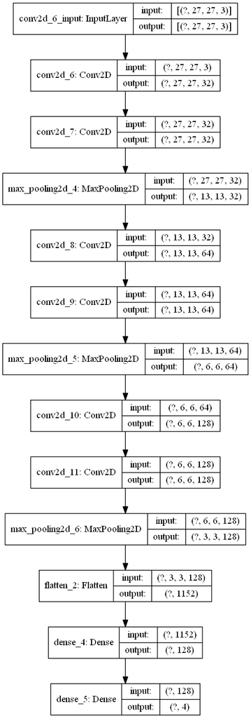

```python
OUTPUT_CLASSES = 4

model_VGG_1 = tf.keras.Sequential([
    #VGG block 1
    tf.keras.layers.Conv2D(32, (3, 3), activation='relu', padding='same', input_shape=(27, 27, 3)),
    tf.keras.layers.Conv2D(32, (3, 3), activation='relu', padding='same'),
    tf.keras.layers.MaxPooling2D((2, 2)),

    #VGG block 2
    tf.keras.layers.Conv2D(64, (3, 3), activation='relu', padding='same'),
    tf.keras.layers.Conv2D(64, (3, 3), activation='relu', padding='same'),
    tf.keras.layers.MaxPooling2D((2, 2)),

    #VGG block 3
    tf.keras.layers.Conv2D(128, (3, 3), activation='relu', padding='same'),
    tf.keras.layers.Conv2D(128, (3, 3), activation='relu', padding='same'),
    tf.keras.layers.MaxPooling2D((2, 2)),

    tf.keras.layers.Flatten(),
    tf.keras.layers.Dense(128, activation='relu'),
    tf.keras.layers.Dense(OUTPUT_CLASSES),
])

model_VGG_1.summary()
tf.keras.utils.plot_model(model_VGG_1, show_shapes=True)
```

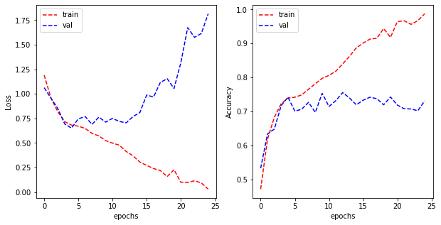

```python
model_VGG_1.compile(optimizer='adam',
              loss=tf.keras.losses.CategoricalCrossentropy(from_logits=True),
              metrics=['categorical_accuracy'])

history_VGG_1 = model_VGG_1.fit_generator(train_generator_small, validation_data = validation_generator_small, epochs=25, verbose=0)

plot_learning_curve(history_VGG_1.history['loss'], history_VGG_1.history['val_loss'],
                    history_VGG_1.history['categorical_accuracy'], history_VGG_1.history['val_categorical_accuracy'],
                    metric_name='Accuracy')
```

Observation: We observe that the model is over-fitted to the train set, thus we would need to do regularization using data augmentation, then we might try to improve the performance further using keras tuner to tune the hyperparameters

## Regularization with data augmentation (VGG)

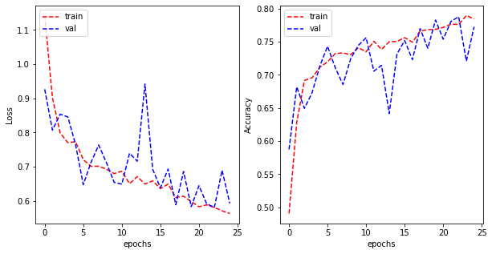

```python
model_VGG_2 = tf.keras.Sequential([
    #VGG block 1
    tf.keras.layers.Conv2D(32, (3, 3), activation='relu', padding='same', input_shape=(27, 27, 3)),
    tf.keras.layers.Conv2D(32, (3, 3), activation='relu', padding='same'),
    tf.keras.layers.MaxPooling2D((2, 2)),

    #VGG block 2
    tf.keras.layers.Conv2D(64, (3, 3), activation='relu', padding='same'),
    tf.keras.layers.Conv2D(64, (3, 3), activation='relu', padding='same'),
    tf.keras.layers.MaxPooling2D((2, 2)),

    #VGG block 3
    tf.keras.layers.Conv2D(128, (3, 3), activation='relu', padding='same'),
    tf.keras.layers.Conv2D(128, (3, 3), activation='relu', padding='same'),
    tf.keras.layers.MaxPooling2D((2, 2)),

    tf.keras.layers.Flatten(),
    tf.keras.layers.Dense(128, activation='relu'),
    tf.keras.layers.Dense(OUTPUT_CLASSES),
])

model_VGG_2.compile(optimizer='adam',
              loss=tf.keras.losses.CategoricalCrossentropy(from_logits=True),
              metrics=['categorical_accuracy'])

history_VGG_2 = model_VGG_2.fit_generator(train_generator_data_aug1, validation_data = validation_generator_small, epochs=25, verbose=0)

plot_learning_curve(history_VGG_2.history['loss'], history_VGG_2.history['val_loss'],
                    history_VGG_2.history['categorical_accuracy'], history_VGG_2.history['val_categorical_accuracy'],
                    metric_name='Accuracy')
```

## Tuning with keras tuner

```python
OUTPUT_CLASSES = 4
import kerastuner as kt

def model_builder(hp):
    # Selection ranges
    # Dense layer unit value
    hp_units = hp.Int('units', min_value=32, max_value=256, step=32)
    # activation function choice
    hp_activations = hp.Choice('activation', values=['sigmoid', 'softmax'])

    # initialize layers
    model = tf.keras.Sequential([
        #VGG block 1
        tf.keras.layers.Conv2D(32, (3, 3), activation='relu', padding='same', input_shape=(27, 27, 3)),
        tf.keras.layers.Conv2D(32, (3, 3), activation='relu', padding='same'),
        tf.keras.layers.MaxPooling2D((2, 2)),

        #VGG block 2
        tf.keras.layers.Conv2D(64, (3, 3), activation='relu', padding='same'),
        tf.keras.layers.Conv2D(64, (3, 3), activation='relu', padding='same'),
        tf.keras.layers.MaxPooling2D((2, 2)),

        #VGG block 3
        tf.keras.layers.Conv2D(128, (3, 3), activation='relu', padding='same'),
        tf.keras.layers.Conv2D(128, (3, 3), activation='relu', padding='same'),
        tf.keras.layers.MaxPooling2D((2, 2)),

        tf.keras.layers.Flatten(),
        tf.keras.layers.Dense(hp_units, activation=hp_activations),
        tf.keras.layers.Dense(OUTPUT_CLASSES),
    ])


    # compile model
    model.compile(optimizer='adam',
              loss=tf.keras.losses.CategoricalCrossentropy(from_logits=True),
              metrics=['categorical_accuracy'])

    return model

# Instantiate the tuner and perform hypertuning
tuner = kt.Hyperband(model_builder,
                     objective='val_categorical_accuracy',
                     max_epochs=20,
                     factor=3,
                     directory='keras',
                     project_name='v4')

# Early stopping callback
stop_early = tf.keras.callbacks.EarlyStopping(monitor='val_loss', patience=5)

# extracting the image and labels from the generators as search function does not support generators directly
train_img_vgg,train_lables_vgg = train_generator_data_aug1.next()
val_img_vgg,val_lables_vgg = validation_generator_small.next()
```

```python
# Execute search
tuner.search(train_img_vgg,train_lables_vgg,
             validation_data=(val_img_vgg,val_lables_vgg),batch_size = 32, callbacks=[stop_early])
# tuner.search(train_img,train_lables,
#              validation_data=(val_img,val_lables),batch_size = 32)

# Print optimal hyperparameters
best_hps=tuner.get_best_hyperparameters(num_trials=1)[0]

print(f"""
 units: {best_hps.get('units')}
 activation: {best_hps.get('activation')}
""")
```

```
Trial 22 Complete [00h 00m 02s]
val_categorical_accuracy: 0.40625

Best val_categorical_accuracy So Far: 0.5
Total elapsed time: 00h 00m 46s
INFO:tensorflow:Oracle triggered exit

 units: 128
 activation: sigmoid
```

### Model with keras tuner's optimal parameters

```
Model: "sequential_1"
_________________________________________________________________
Layer (type)                 Output Shape              Param #
=================================================================
conv2d_6 (Conv2D)            (None, 27, 27, 32)        896
_________________________________________________________________
conv2d_7 (Conv2D)            (None, 27, 27, 32)        9248
_________________________________________________________________
max_pooling2d_3 (MaxPooling2 (None, 13, 13, 32)        0
_________________________________________________________________
conv2d_8 (Conv2D)            (None, 13, 13, 64)        18496
_________________________________________________________________
conv2d_9 (Conv2D)            (None, 13, 13, 64)        36928
_________________________________________________________________
max_pooling2d_4 (MaxPooling2 (None, 6, 6, 64)          0
_________________________________________________________________
conv2d_10 (Conv2D)           (None, 6, 6, 128)         73856
_________________________________________________________________
conv2d_11 (Conv2D)           (None, 6, 6, 128)         147584
_________________________________________________________________
max_pooling2d_5 (MaxPooling2 (None, 3, 3, 128)         0
_________________________________________________________________
flatten_1 (Flatten)          (None, 1152)              0
_________________________________________________________________
dense_2 (Dense)              (None, 128)               147584
_________________________________________________________________
dense_3 (Dense)              (None, 4)                 516
=================================================================
Total params: 435,108
Trainable params: 435,108
Non-trainable params: 0
_________________________________________________________________
```

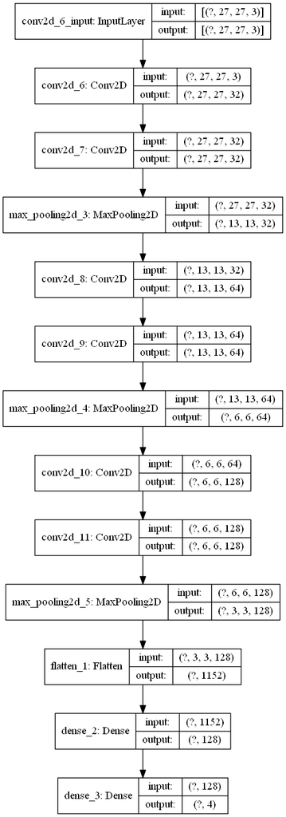

```python
units = 128

model_VGG_3 = tf.keras.Sequential([
    #VGG block 1
    tf.keras.layers.Conv2D(32, (3, 3), activation='relu', padding='same', input_shape=(27, 27, 3)),
    tf.keras.layers.Conv2D(32, (3, 3), activation='relu', padding='same'),
    tf.keras.layers.MaxPooling2D((2, 2)),

    #VGG block 2
    tf.keras.layers.Conv2D(64, (3, 3), activation='relu', padding='same'),
    tf.keras.layers.Conv2D(64, (3, 3), activation='relu', padding='same'),
    tf.keras.layers.MaxPooling2D((2, 2)),

    #VGG block 3
    tf.keras.layers.Conv2D(128, (3, 3), activation='relu', padding='same'),
    tf.keras.layers.Conv2D(128, (3, 3), activation='relu', padding='same'),
    tf.keras.layers.MaxPooling2D((2, 2)),

    tf.keras.layers.Flatten(),
    tf.keras.layers.Dense(units, activation='sigmoid'),
    tf.keras.layers.Dense(OUTPUT_CLASSES),
])

model_VGG_3.summary()
tf.keras.utils.plot_model(model_VGG_3, show_shapes=True)
```

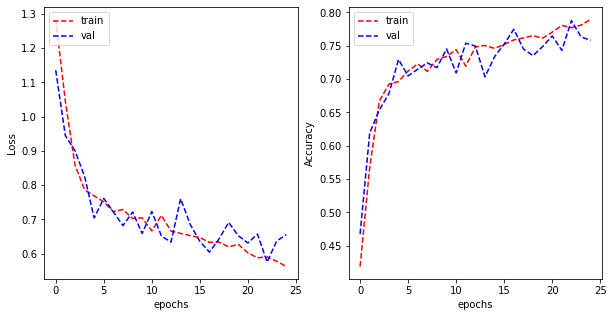

```python
model_VGG_3.compile(optimizer='adam',
              loss=tf.keras.losses.CategoricalCrossentropy(from_logits=True),
              metrics=['categorical_accuracy'])

history_VGG_3 = model_VGG_3.fit_generator(train_generator_data_aug1, validation_data = validation_generator_small, epochs=25, verbose=0)

plot_learning_curve(history_VGG_3.history['loss'], history_VGG_3.history['val_loss'],
                    history_VGG_3.history['categorical_accuracy'], history_VGG_3.history['val_categorical_accuracy'],
                    metric_name='Accuracy')
```

## Testing with test set (VGG)

```python
model_VGG_1.evaluate(test_generator_small)
```

```
[1.9086999893188477, 0.7265512347221375]
```

```python
model_VGG_2.evaluate(test_generator_small)
```

```
[0.6090120077133179, 0.7691197395324707]
```

```python
model_VGG_3.evaluate(test_generator_small)
```

```
[0.6636852622032166, 0.7467532753944397]
```

```python
# setup data some placeholders
y_hat_all_VGG_1 = list()
y_all_VGG_1 = list()
filenames = test_generator_small.filenames
N_images = len(filenames)
batches = 0

# iterate through the data generator and predict for each batch
# hold the predictions and labels
for x,y in test_generator_small:
        y_hat = model_VGG_1.predict(x, verbose=0)
        y_hat = np.argmax(y_hat, axis = 1)
        y = np.argmax(y, axis = 1)
        y_hat_all_VGG_1 = y_hat_all_VGG_1 + y_hat.tolist()
        y_all_VGG_1 = y_all_VGG_1 + y.tolist()

        batches += 1
        if batches >= N_images / batch_size:
            # we need to break the loop by hand because
            # the generator loops indefinitely
            break
```

```python
print(classification_report(y_all_VGG_1, y_hat_all_VGG_1,))
```

```
              precision    recall  f1-score   support

           0       0.62      0.67      0.65       276
           1       0.72      0.71      0.72       351
           2       0.83      0.90      0.86       554
           3       0.50      0.34      0.40       205

    accuracy                           0.73      1386
   macro avg       0.67      0.66      0.66      1386
weighted avg       0.71      0.73      0.72      1386
```

```python
# setup data some placeholders
y_hat_all_VGG_2 = list()
y_all_VGG_2 = list()
filenames = test_generator_small.filenames
N_images = len(filenames)
batches = 0

# iterate through the data generator and predict for each batch
# hold the predictions and labels
for x,y in test_generator_small:
        y_hat = model_VGG_2.predict(x, verbose=0)
        y_hat = np.argmax(y_hat, axis = 1)
        y = np.argmax(y, axis = 1)
        y_hat_all_VGG_2 = y_hat_all_VGG_2 + y_hat.tolist()
        y_all_VGG_2 = y_all_VGG_2 + y.tolist()

        batches += 1
        if batches >= N_images / batch_size:
            # we need to break the loop by hand because
            # the generator loops indefinitely
            break
```

```python
print(classification_report(y_all_VGG_2, y_hat_all_VGG_2,))
```

```
              precision    recall  f1-score   support

           0       0.74      0.69      0.72       272
           1       0.64      0.92      0.76       342
           2       0.92      0.87      0.90       561
           3       0.66      0.36      0.46       211

    accuracy                           0.77      1386
   macro avg       0.74      0.71      0.71      1386
weighted avg       0.78      0.77      0.76      1386
```

```python
# setup data some placeholders
y_hat_all_VGG_3 = list()
y_all_VGG_3 = list()
filenames = test_generator_small.filenames
N_images = len(filenames)
batches = 0

# iterate through the data generator and predict for each batch
# hold the predictions and labels
for x,y in test_generator_small:
        y_hat = model_VGG_3.predict(x, verbose=0)
        y_hat = np.argmax(y_hat, axis = 1)
        y = np.argmax(y, axis = 1)
        y_hat_all_VGG_3 = y_hat_all_VGG_3 + y_hat.tolist()
        y_all_VGG_3 = y_all_VGG_3 + y.tolist()

        batches += 1
        if batches >= N_images / batch_size:
            # we need to break the loop by hand because
            # the generator loops indefinitely
            break
```

```python
print(classification_report(y_all_VGG_3, y_hat_all_VGG_3,))
```

```
              precision    recall  f1-score   support

           0       0.83      0.49      0.62       289
           1       0.65      0.82      0.73       346
           2       0.87      0.93      0.90       545
           3       0.50      0.47      0.48       206

    accuracy                           0.74      1386
   macro avg       0.71      0.68      0.68      1386
weighted avg       0.75      0.74      0.74      1386
```

Observation: Although we observe that the 2nd model (only with data aug) again has the best performance compared to the 3rd model (which has data aug + hyper params tuning), the 3rd model has a slightly better f1-score for cellType = 3.